# Homework 1

your name here

18 September, 2023

**Due September 13, 2023, prior to 1:30 PM. Assignments are to be submitted via Canvas.**

**You may discuss the homework problems and computing issues with other students in the class and submit questions to the Canvas discussion board. However, you must write up your homework solution on your own. In particular, do not share your R files with other students. Please list the students you worked with below:**

Students worked with: XXXXX

Lectures: Module 1

Objectives:

1. Familiarize yourself with R, which will be used throughout BIOS 526. Also make good use of the R help files when learning new commands.
2. Review concepts from linear regression and multiple linear regression.
3. Start working with observations that are not independent.
4. Evaluate the influence of omitted variables on an analysis.
5. Interpret interaction effects.

# 1 Problem 1.

We will be using a dataset from a study on the impacts of image acquisition method on measures of brain activity. FMRI is a non-invasive technique that can be used to measure brain activity across time. Resting-state fMRI is acquired while a participant stares at a crosshair and performs no specific task. Nine 6-min rs-fMRI scans were collected on 32 healthy young adults. Scans differed by their “multiband factor,” which is a technique that allows more time points to be collected in the same amount of time. Although more data is collected, the data may be noisier. The data measures activity between two brain regions: one is located in the left thalamus and the other in the right thalamus. The thalamus relays information between brain regions.

We will examine whether brain activity differs when measured using two acquisitions: SB.3.3 and MB.4. SB.3.3.mm is a single-band acquisition with larger voxels, and similar acquisitions were used in most studies prior to around 2016. MB4 is an accelerated sequence that collects more data in the same amount of time, and in this study, used a 2 mm acquisition. We collected these data in my lab, and the paper is available [here](https://www.sciencedirect.com/science/article/pii/S1053811921002421).

We will focus on the following variables:

`id` is subject ID.

`zcor` is the measure of brain activity (a Fisher z-fransformed correlation)

`Acquisition` is the scan used to acquire the data.

The data are in the “long” format.

## 1.1

First, use the `lm()` function to compare the mean brain activity in SB.3.3.mm to MB.4, and print the output of `summary()`. No need to interpret the results yet. You can use the code below to subset to these two acquisitions. Note the use of `%in%`, which is a helpful R function.

```r
# set the working directory
# read in the dataset
mbdata = read.csv("thalamus_mb_selected.csv")
# subset the dataset
mbdata_sel = mbdata[mbdata$Acquisition %in% c("SB.3.3.mm","MB.4"),c("id","Acquisition","zcor")]
```

```r
# fit the linear model
model.lm = lm(zcor~Acquisition,data=mbdata_sel)
# output the summary() results
summary(model.lm)
```

```
##
## Call:
## lm(formula = zcor ~ Acquisition, data = mbdata_sel)
##
## Residuals:
##      Min       1Q   Median       3Q      Max
## -0.50449 -0.24029 -0.05592  0.21590  0.64997
##
## Coefficients:
##                      Estimate Std. Error t value Pr(>|t|)
## (Intercept)           0.57522    0.04983  11.543  < 2e-16 ***
## AcquisitionSB.3.3.mm  0.31104    0.07047   4.414  4.3e-05 ***
## ---
## Signif. codes:  0 '***' 0.001 '**' 0.01 '*' 0.05 '.' 0.1 ' ' 1
##
## Residual standard error: 0.2775 on 60 degrees of freedom
##   (2 observations deleted due to missingness)
## Multiple R-squared:  0.2451, Adjusted R-squared:  0.2325
## F-statistic: 19.48 on 1 and 60 DF,  p-value: 4.303e-05
```

## 1.2

Now check model diagnostics using `plot()`. Describe each of the four plots and any issues.

```
## hat values (leverages) are all = 0.03225806
##  and there are no factor predictors; no plot no. 5
```

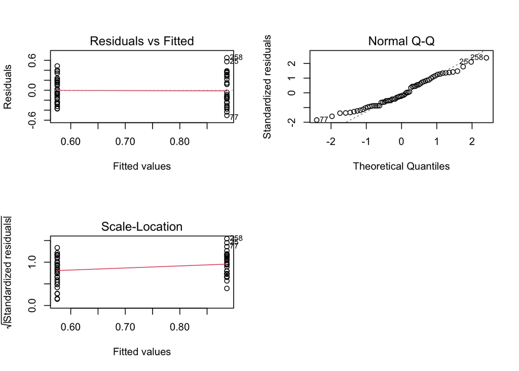

```r
# arrange the plots
par(mfrow = c(2,2))
# plot the diagnostics plots
plot(model.lm)
```

The first plot is used to check the linearity assumption. Since there is only a single binary variable, this line is flat.

The second plot is used to check the normality assumption. There are some departures in the tails.

The third plot is used to check the homoscedasticity. As can be seen, the red line slightly increases, indicating that the variance is somewhat higher in one of the acquisitions than in the other (here, SB.3.3.mm is slightly higher than MB.4).

## 1.3

Based on what we know about the data, are there any other model assumptions that may be violated?

The assumption of independence may be violated. SB.3.3.mm and MB.4 are repeatedly measured on the same subject, which are not independent.

## 1.4

Next we will use a t-test to compare SB.3.3.mm and MB.4. It is helpful to reshape the data into “wide” format.

```r
library(tidyr)
mbdata_sel_wide = mbdata_sel %>% pivot_wider(names_from = Acquisition, values_from = zcor)
```

Conduct a t-test using `t.test()`. For this problem, use `paired=FALSE` and `var.equal=TRUE`. How do the estimates, t-statistic, and p-value compare to `lm()`?

```r
t.test(mbdata_sel_wide$SB.3.3.mm,mbdata_sel_wide$MB.4, paired = FALSE, var.equal=TRUE)
```

```
##
##  Two Sample t-test
##
## data:  mbdata_sel_wide$SB.3.3.mm and mbdata_sel_wide$MB.4
## t = 4.4136, df = 60, p-value = 4.303e-05
## alternative hypothesis: true difference in means is not equal to 0
## 95 percent confidence interval:
##  0.1700740 0.4520114
## sample estimates:
## mean of x mean of y
## 0.8862588 0.5752161
```

The two sample t-test is used to test the null hypothesis that there is no difference between two group means. Based on the results above, we reject the null hypothesis ($p<0.05$) and conclude that the difference between the mean zcor measured in SB.3.3.mm and MB.4 is statistically significant. The results will be exactly the same as one from `lm()`.

## 1.5

Next, conduct the t-test but with `var.equal=FALSE` (keep `paired=FALSE` for now). How does the estimate, t-statistic, degrees of freedom, and p-value compare to the previous problem?

```r
t.test(mbdata_sel_wide$SB.3.3.mm,mbdata_sel_wide$MB.4, paired = FALSE, var.equal=FALSE)
```

```
##
##  Welch Two Sample t-test
##
## data:  mbdata_sel_wide$SB.3.3.mm and mbdata_sel_wide$MB.4
## t = 4.4136, df = 56.189, p-value = 4.664e-05
## alternative hypothesis: true difference in means is not equal to 0
## 95 percent confidence interval:
##  0.1698771 0.4522083
## sample estimates:
## mean of x mean of y
## 0.8862588 0.5752161
```

The estimates and t-statistics are the same but the df decreases to 56.189, and p-value slightly increases.

## 1.6

Next, conduct a paired t test. Print the output (no interpretation necessary).

```r
t.test(mbdata_sel_wide$SB.3.3.mm,mbdata_sel_wide$MB.4,paired = TRUE)
```

```
##
##  Paired t-test
##
## data:  mbdata_sel_wide$SB.3.3.mm and mbdata_sel_wide$MB.4
## t = 5.1113, df = 29, p-value = 1.862e-05
## alternative hypothesis: true difference in means is not equal to 0
## 95 percent confidence interval:
##  0.1969103 0.4596117
## sample estimates:
## mean of the differences
##                0.328261
```

## 1.7

How do the estimates, t-statistics, degrees of freedom, and p values compare in the paired and unpaired versions? (Compare the paired t.test to the t.test with `paired=FALSE` and `var.equal=FALSE` from the previous problem.)

The paired t-test has a larger estimates (0.328 vs. 0.886 - 0.575 = 0.311), larger t-statistic (5.1113 vs. 4.4136), smaller degrees of freedom (29 vs. 56.189), and smaller p-value (1.862e-05 vs. 4.664e-05) compared to the previous unpaired t-test with `var.equal=FALSE`.

Here, the estimate of the difference in mean differs from the previous questions because a couple participants were missing one of the acquisitions. When all the data are the same, the estimate of the difference does not vary between the paired and unpaired t-tests. See the example below:

```r
temp = mbdata_sel_wide[complete.cases(mbdata_sel_wide),]
t.test(temp$SB.3.3.mm,temp$MB.4)
```

```
##
##  Welch Two Sample t-test
##
## data:  temp$SB.3.3.mm and temp$MB.4
## t = 4.5826, df = 54.644, p-value = 2.707e-05
## alternative hypothesis: true difference in means is not equal to 0
## 95 percent confidence interval:
##  0.1846863 0.4718357
## sample estimates:
## mean of x mean of y
##  0.897887  0.569626
```

```r
0.897887-0.569626
```

```
## [1] 0.328261
```

## 1.8

Now create a new variable that subtracts SB.3.3.mm from MB.4, and then conduct a one-sample t-test to test whether the mean of the differences differs from zero. How does this compare to the paired t test?

```r
diff = mbdata_sel_wide$MB.4 - mbdata_sel_wide$SB.3.3.mm
t.test(diff)
```

```
##
##  One Sample t-test
##
## data:  diff
## t = -5.1113, df = 29, p-value = 1.862e-05
## alternative hypothesis: true mean is not equal to 0
## 95 percent confidence interval:
##  -0.4596117 -0.1969103
## sample estimates:
## mean of x
## -0.328261
```

The result of one sample t-test is the same as that of the paired t-test.

## 1.9

Calculate the sample covariance between MB.4 and SB.3.3.mm using the R function `cov()`. Hint: specify the `complete.obs` option (see `?cov`).

```r
cov(mbdata_sel_wide$MB.4,mbdata_sel_wide$SB.3.3.mm,use = 'complete.obs')
```

```
## [1] 0.01509832
```

## 1.10

Now calculate the standard error of the paired t-test using the variance of MB.4, SB.3.3.mm, and their covariance. Do this using the R functions `var()` as well as `cov()`. Check that your value matches the SE output by the paired t-test, which can be viewed using `t.test()$stderr`. (Use the discussion board if you have issues or questions.) Does the covariance increase or decrease the test statistic? Hint: subset to complete observations before doing this, e.g., `mydata[complete.cases(mydata),]`

```r
# subset complete observations
mbtemp = mbdata_sel_wide[complete.cases(mbdata_sel_wide),]
sqrt((var(mbtemp$MB.4)+var(mbtemp$SB.3.3.mm)-2*cov(mbtemp$MB.4,mbtemp$SB.3.3.mm))/nrow(mbtemp))
```

```
## [1] 0.06422296
```

```r
# SE output by the paired t-test
t.test(diff)$stderr
```

```
## [1] 0.06422296
```

The covariance increases the test statistic.

Additional information: In general, the covariance *helps* statistical power in a paired t-test because it is usually positive, and hence when subtracted, leads to a smaller standard error, which leads to a larger test statistic. For example, in experimental design, an experiment examining the effect of a drug is generally more powerful when an outcome is observed before and after a drug than say an experimental design that examines one cohort on a drug and a second cohort off the drug.

## 1.11

How does brain activity in the thalamus measured using the multiband 4 with 2 mm resolution compare to single band with 3.3 mm resolution? State your null hypothesis, report the p value and state your conclusion, along with your chosen $\alpha$-level.

A paired t-test is used to test the null hypothesis that there is no difference between mean brain activity in the thalamus measured using the multiband 4 with 2 mm resolution compare to single band with 3.3 mm resolution. The p-value for paired t-test is 1.862e-05. Given an $\alpha$ level of 0.05, we reject the null hypothesis and conclude that the difference between the mean brain activity in the thalamus measured in SB.3.3.mm and MB.4 is statistically significant.

# 2 Problem 2.

Dataset: parkinsons.csv

In this problem, we will examine whether dysphonia, or abnormal speech sounds, are related to Parkinson’s disease severity. This dataset was obtained from https://data.world/uci/parkinsons-telemonitoring/. The response variable we will examine is `motor_UPDRS` (motor Unified Parkinson’s Disease Rating Scale). The scientific question is whether Parkinson’s severity can be monitored using features derived from speech recordings, which can be collected by telephone. The gold standard for monitoring disease progression, the UPDRS, is administered in a clinic, and hence is costly and burdensome.

There are nearly 6000 observations in this dataset, which are collected on 42 subjects.

## 2.1

First, we will examine a “fixed effects” model that has a separate intercept for every subject. We will learn more about these in Module 2. We will be revisiting this dataset in future homeworks to improve our modeling. Fit a linear model for `motor_UPDRS` with the terms `subject` (as a factor), `age`, and `sex`. What are the coefficients for `age` and `sex`? Did R produce any errors, warnings, or other notable output? (Hint: look at the output carefully.)

```r
# read in dataset
pdata = read.csv('parkinsons.csv')
# factorize the variable "subject"
pdata$subject = as.factor(pdata$subject)
# model fitting
model2.1 = lm(motor_UPDRS~subject+age+sex,data=pdata)
# output the summary of fitted model
summary(model2.1)
```

```
##
## Call:
## lm(formula = motor_UPDRS ~ subject + age + sex, data = pdata)
##
## Residuals:
##     Min      1Q  Median      3Q     Max
## -8.8986 -1.3124  0.0791  1.2119 10.4183
##
## Coefficients: (2 not defined because of singularities)
##              Estimate Std. Error t value Pr(>|t|)
## (Intercept)  31.89893    0.19174 166.366  < 2e-16 ***
## subject2    -18.08639    0.27302 -66.245  < 2e-16 ***
## subject3     -4.77415    0.27350 -17.456  < 2e-16 ***
## subject4    -16.10811    0.27703 -58.145  < 2e-16 ***
## subject5     -0.26633    0.26810  -0.993    0.321
## subject6     -4.36724    0.26810 -16.290  < 2e-16 ***
## subject7    -15.85187    0.26606 -59.580  < 2e-16 ***
## subject8    -12.01191    0.27071 -44.372  < 2e-16 ***
## subject9    -13.58657    0.26982 -50.354  < 2e-16 ***
## subject10   -18.47451    0.27162 -68.017  < 2e-16 ***
## subject11   -12.91137    0.27651 -46.694  < 2e-16 ***
## subject12   -15.01065    0.29658 -50.613  < 2e-16 ***
## subject13   -12.38217    0.29270 -42.303  < 2e-16 ***
## subject14   -18.88448    0.27756 -68.036  < 2e-16 ***
## subject15   -17.93435    0.27399 -65.456  < 2e-16 ***
## subject16   -23.19297    0.27651 -83.877  < 2e-16 ***
## subject17    -5.46663    0.27350 -19.987  < 2e-16 ***
## subject18   -26.07547    0.28326 -92.053  < 2e-16 ***
## subject19   -14.28771    0.28147 -50.760  < 2e-16 ***
## subject20   -20.71548    0.27865 -74.344  < 2e-16 ***
## subject21    -2.80627    0.28513  -9.842  < 2e-16 ***
## subject22   -22.09922    0.29270 -75.501  < 2e-16 ***
## subject23   -18.42430    0.27651 -66.631  < 2e-16 ***
## subject24   -18.13920    0.26810 -67.658  < 2e-16 ***
## subject25    -3.16637    0.27350 -11.577  < 2e-16 ***
## subject26    -6.85869    0.28089 -24.417  < 2e-16 ***
## subject27   -21.10710    0.28147 -74.988  < 2e-16 ***
## subject28    -2.73155    0.27865  -9.803  < 2e-16 ***
## subject29    -7.26771    0.26338 -27.594  < 2e-16 ***
## subject30    -5.98381    0.28326 -21.124  < 2e-16 ***
## subject31    -5.49465    0.28089 -19.561  < 2e-16 ***
## subject32   -21.95467    0.30166 -72.779  < 2e-16 ***
## subject33    -5.53062    0.27810 -19.887  < 2e-16 ***
## subject34    -7.21804    0.26606 -27.129  < 2e-16 ***
## subject35     4.09088    0.26450  15.466  < 2e-16 ***
## subject36    -8.50399    0.28147 -30.212  < 2e-16 ***
## subject37    -0.03829    0.27548  -0.139    0.889
## subject38   -12.12634    0.27116 -44.720  < 2e-16 ***
## subject39    -2.02137    0.27399  -7.378 1.84e-13 ***
## subject40   -15.39147    0.27448 -56.075  < 2e-16 ***
## subject41     2.50599    0.26450   9.474  < 2e-16 ***
## subject42    -9.05487    0.27071 -33.449  < 2e-16 ***
## age                NA         NA      NA       NA
## sex                NA         NA      NA       NA
## ---
## Signif. codes:  0 '***' 0.001 '**' 0.01 '*' 0.05 '.' 0.1 ' ' 1
##
## Residual standard error: 2.34 on 5833 degrees of freedom
## Multiple R-squared:  0.9177, Adjusted R-squared:  0.9171
## F-statistic:  1586 on 41 and 5833 DF,  p-value: < 2.2e-16
```

The coefficients for age and sex are NA. R produced a message saying “Coefficient: (2 not defined because of singularities)”, although no warning was printed in red.

## 2.2

Why were coefficients for `age` and `sex` not estimated? Mathematically, what can we say about the columns of the design matrix?

This is because the design matrix is a sigular matrix rather than full rank , that is, the columns of the design matrix are not linearly independent with each other. Mathematically, the columns corresponding to sex and age are linear combinations of the columns corresponding to the other independent variables.

## 2.3

Drop `age` and `sex` from the model, and fit the model with all dysphonia predictors and subject (as a factor). DO NOT INCLUDE `total_UPDRS`. Calculate the VIFs. Hint: you can use the shorthand `motor_UPDRS~.-age-sex-total_UPDRS` to include all variables in the dataset except those with the minus sign. Is multicollinearity an issue?

```r
model2.2 = lm(motor_UPDRS~.-age-sex-total_UPDRS,data=pdata)
summary(model2.2)
```

```
##
## Call:
## lm(formula = motor_UPDRS ~ . - age - sex - total_UPDRS, data = pdata)
##
## Residuals:
##     Min      1Q  Median      3Q     Max
## -9.4832 -1.1711  0.0382  1.2034  9.1948
##
## Coefficients:
##                  Estimate Std. Error t value Pr(>|t|)
## (Intercept)     3.140e+01  9.687e-01  32.415  < 2e-16 ***
## subject2       -1.755e+01  3.195e-01 -54.942  < 2e-16 ***
## subject3       -4.790e+00  2.656e-01 -18.036  < 2e-16 ***
## subject4       -1.566e+01  2.947e-01 -53.152  < 2e-16 ***
## subject5        1.349e-01  2.764e-01   0.488 0.625424
## subject6       -4.079e+00  2.731e-01 -14.935  < 2e-16 ***
## subject7       -1.561e+01  2.764e-01 -56.494  < 2e-16 ***
## subject8       -1.183e+01  2.745e-01 -43.111  < 2e-16 ***
## subject9       -1.347e+01  3.259e-01 -41.315  < 2e-16 ***
## subject10      -1.834e+01  2.770e-01 -66.208  < 2e-16 ***
## subject11      -1.278e+01  2.760e-01 -46.310  < 2e-16 ***
## subject12      -1.475e+01  2.941e-01 -50.146  < 2e-16 ***
## subject13      -1.220e+01  2.877e-01 -42.401  < 2e-16 ***
## subject14      -1.879e+01  2.787e-01 -67.433  < 2e-16 ***
## subject15      -1.830e+01  2.746e-01 -66.631  < 2e-16 ***
## subject16      -2.274e+01  3.021e-01 -75.288  < 2e-16 ***
## subject17      -5.429e+00  2.733e-01 -19.864  < 2e-16 ***
## subject18      -2.585e+01  2.830e-01 -91.343  < 2e-16 ***
## subject19      -1.410e+01  3.092e-01 -45.597  < 2e-16 ***
## subject20      -2.035e+01  3.296e-01 -61.744  < 2e-16 ***
## subject21      -2.446e+00  2.957e-01  -8.273  < 2e-16 ***
## subject22      -2.212e+01  3.011e-01 -73.480  < 2e-16 ***
## subject23      -1.816e+01  2.966e-01 -61.248  < 2e-16 ***
## subject24      -1.748e+01  3.265e-01 -53.530  < 2e-16 ***
## subject25      -2.898e+00  2.818e-01 -10.281  < 2e-16 ***
## subject26      -6.465e+00  3.153e-01 -20.505  < 2e-16 ***
## subject27      -2.081e+01  3.147e-01 -66.122  < 2e-16 ***
## subject28      -2.318e+00  3.188e-01  -7.269 4.09e-13 ***
## subject29      -7.324e+00  2.663e-01 -27.506  < 2e-16 ***
## subject30      -5.541e+00  3.204e-01 -17.297  < 2e-16 ***
```

[output cut: 20 more lines]

```
## Shimmer.APQ3    4.239e+03  1.088e+04   0.390 0.696802
## Shimmer.APQ5   -1.085e+01  1.307e+01  -0.830 0.406488
## Shimmer.APQ11  -2.518e+00  5.925e+00  -0.425 0.670881
## Shimmer.DDA    -1.424e+03  3.627e+03  -0.393 0.694531
## NHR            -4.757e+00  1.592e+00  -2.988 0.002816 **
## HNR             3.495e-02  2.050e-02   1.705 0.088249 .
## RPDE           -3.737e-01  5.208e-01  -0.718 0.473075
## DFA            -2.415e+00  9.641e-01  -2.505 0.012278 *
## PPE             3.509e-01  7.748e-01   0.453 0.650582
## ---
## Signif. codes:  0 '***' 0.001 '**' 0.01 '*' 0.05 '.' 0.1 ' ' 1
##
## Residual standard error: 2.245 on 5816 degrees of freedom
## Multiple R-squared:  0.9245, Adjusted R-squared:  0.9237
## F-statistic:  1227 on 58 and 5816 DF,  p-value: < 2.2e-16
```

```r
library(car)
vif(model2.2)
```

```
##                        GVIF Df GVIF^(1/(2*Df))
## subject        3.179809e+02 41        1.072796
## test_time      1.036421e+00  1        1.018047
## Jitter_Percent 1.066964e+02  1       10.329396
## Jitter_ABS     1.096753e+01  1        3.311726
## Jitter.RAP     1.336633e+06  1     1156.128577
## Jitter.PPQ5    3.613960e+01  1        6.011622
## Jitter.DDP     1.336946e+06  1     1156.263631
## Shimmer        1.850068e+02  1       13.601722
## Shimmer.dB.    8.283751e+01  1        9.101511
## Shimmer.APQ3   2.416872e+07  1     4916.169667
## Shimmer.APQ5   5.529998e+01  1        7.436396
## Shimmer.APQ11  1.633843e+01  1        4.042082
## Shimmer.DDA    2.416828e+07  1     4916.124421
## NHR            1.052015e+01  1        3.243477
## HNR            9.017169e+00  1        3.002860
## RPDE           3.223475e+00  1        1.795404
## DFA            5.444610e+00  1        2.333369
## PPE            5.855532e+00  1        2.419821
```

Some of the VIFs are greater than 5, thus multicollinearity is an issue in this model.

## 2.4

We will restrict the analysis to a few variables. In the following, we will use the variables `age`, `sex`, `Jitter_Percent`, `Shimmer`, `NHR`, and `PPE`. Fit the model with these predictors. Check their VIFs. Are there issues with multicollinearity?

```r
model2.3 = lm(motor_UPDRS~age+sex+Jitter_Percent+Shimmer+NHR+PPE,data=pdata)
summary(model2.3)
```

```
##
## Call:
## lm(formula = motor_UPDRS ~ age + sex + Jitter_Percent + Shimmer +
##     NHR + PPE, data = pdata)
##
## Residuals:
##     Min      1Q  Median      3Q     Max
## -17.360  -6.341  -0.412   6.505  20.221
##
## Coefficients:
##                  Estimate Std. Error t value Pr(>|t|)
## (Intercept)       3.44598    0.77803   4.429 9.64e-06 ***
## age               0.23659    0.01167  20.269  < 2e-16 ***
## sex              -0.16087    0.22718  -0.708  0.47891
## Jitter_Percent -101.12600   38.16665  -2.650  0.00808 **
## Shimmer          -4.64893    6.90175  -0.674  0.50060
## NHR               7.36614    3.71071   1.985  0.04718 *
## PPE              14.17625    1.71069   8.287  < 2e-16 ***
## ---
## Signif. codes:  0 '***' 0.001 '**' 0.01 '*' 0.05 '.' 0.1 ' ' 1
##
## Residual standard error: 7.746 on 5868 degrees of freedom
## Multiple R-squared:  0.09307,    Adjusted R-squared:  0.09215
## F-statistic: 100.4 on 6 and 5868 DF,  p-value: < 2.2e-16
```

```r
car::vif(model2.3)
```

```
##            age            sex Jitter_Percent        Shimmer            NHR
##       1.038132       1.095692       4.511366       3.112822       4.803572
##            PPE
##       2.398741
```

There are small issues with multicollinearity, since some VIFs are close to 5.

## 2.5

Without looking at the diagnostic plots, which of the assumptions of linear regression is (or are) violated?

The assumption of independence may be violated. The measurements at different test times are collected on 42 subjects. Hence, the measurements of the same subject are not independent.

## 2.6

Perform model diagnostics using `plot()`. Summarize your interpretation of each of the four plots and whether there are any concerns.

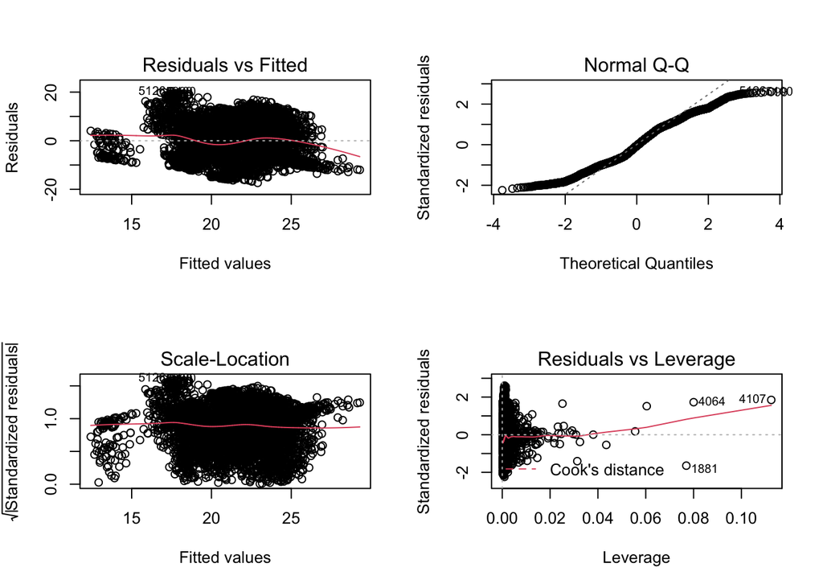

```r
par(mfrow=c(2,2))
plot(model2.3)
```

The first plot is used to check the linearity assumption and homoscedasticity. The red line is not flat, which indicates a violation of the linearity assumption.

The second plot is used to check the normality assumption. It shows some departures at the tails, suggesting a potential violation of normality.

The third plot is used to check the homoscedasticity. By looking at the red line, it is almost flat with minor fluctuations, which doesn’t indicate a severe violation of the homoscedasticity assumption. However, there are two clusters of points in the plot, with the cluster on the left with smaller variance, indicating a possible violation of homoscedasticity.

The last plot is used to check the outliers and influential points. We identified three potential outliers with both large leverages and standardized residuals (4064, 1881, 4107) in the plot. However, they are not flagged as being influential points using Cook’s distance (Cook’s distance < 1), so it is less likely that they are highly influential.

## 2.7

Fit the model without `age`. Does the coefficient of NHR change? Calculate $(\beta_{no-age} - \beta_{adjusted})/\beta_{no-age}$. Here, $\beta_{no-age}$ is the slope of NHR in the model without `age` and $\beta_{adjusted}$ is the slope of NHR in the model from 2.4. Is there evidence of omitted variable bias?

```r
model2.4 = lm(motor_UPDRS~sex+Jitter_Percent+Shimmer+NHR+PPE,data=pdata)

beta_no_age <- coef(model2.4)["NHR"]
beta_adjusted <- coef(model2.3)["NHR"]
percent_change <- ((beta_no_age - beta_adjusted) / beta_no_age) * 100
percent_change
```

```
##       NHR
## -260.1274
```

The coefficient of NHR decreases by around 260% after excluding age, indicating omitted variable bias.

## 2.8

Look at interactions. In the interest of time, we will only look at the interaction between `NHR` and `age`. Does `age` modify the relationship between `NHR` and `motor_UPDRS`?

```r
model2.5 = lm(motor_UPDRS~age+sex+Jitter_Percent+Shimmer+age*NHR+PPE,data=pdata)
summary(model2.5)
```

```
##
## Call:
## lm(formula = motor_UPDRS ~ age + sex + Jitter_Percent + Shimmer +
##     age * NHR + PPE, data = pdata)
##
## Residuals:
##      Min       1Q   Median       3Q      Max
## -17.1657  -6.2567  -0.5255   6.4920  20.4341
##
## Coefficients:
##                  Estimate Std. Error t value Pr(>|t|)
## (Intercept)       0.10950    0.96357   0.114 0.909525
## age               0.28947    0.01475  19.628  < 2e-16 ***
## sex              -0.04240    0.22745  -0.186 0.852130
## Jitter_Percent -133.52952   38.46197  -3.472 0.000521 ***
## Shimmer          -9.48297    6.93198  -1.368 0.171364
## NHR             134.66364   22.11369   6.090 1.20e-09 ***
## PPE              15.32298    1.71715   8.923  < 2e-16 ***
## age:NHR          -1.96831    0.33711  -5.839 5.54e-09 ***
## ---
## Signif. codes:  0 '***' 0.001 '**' 0.01 '*' 0.05 '.' 0.1 ' ' 1
##
## Residual standard error: 7.724 on 5867 degrees of freedom
## Multiple R-squared:  0.09831,    Adjusted R-squared:  0.09724
## F-statistic: 91.39 on 7 and 5867 DF,  p-value: < 2.2e-16
```

```r
anova(model2.3,model2.5)
```

```
## Analysis of Variance Table
##
## Model 1: motor_UPDRS ~ age + sex + Jitter_Percent + Shimmer + NHR + PPE
## Model 2: motor_UPDRS ~ age + sex + Jitter_Percent + Shimmer + age * NHR +
##     PPE
##   Res.Df    RSS Df Sum of Sq      F    Pr(>F)
## 1   5868 352055
## 2   5867 350021  1    2033.9 34.092 5.539e-09 ***
## ---
## Signif. codes:  0 '***' 0.001 '**' 0.01 '*' 0.05 '.' 0.1 ' ' 1
```

A F-test is used to test the null hypothesis that the interaction between `NHR` and `age` does not improve model ﬁt. The p-value of the F-test is 5.539e-09 < 0.05, indicating that age modifies the relationship between NHR and motor_UPDRS.

## 2.9

Interpret the slope of `NHR` in the model including `age*NHR`. Is this biologically reasonable?

After controlling for the other covariates in the model, one unit increase in `NHR` is associated with 134.66364 increases in `motor_UPDRS` for people at age = 0. This interpretation is not biologically reasonable since there is no valid situation where someone can have an age of 0.

## 2.10

Refit the model with `age` centered. Interpret the slope of `NHR`.

```r
model2.6 = lm(motor_UPDRS~sex+Jitter_Percent+Shimmer+scale(age,center = TRUE,scale=FALSE)*NHR+PPE,data=pdata)
summary(model2.6)
```

```
##
## Call:
## lm(formula = motor_UPDRS ~ sex + Jitter_Percent + Shimmer + scale(age,
##     center = TRUE, scale = FALSE) * NHR + PPE, data = pdata)
##
## Residuals:
##      Min       1Q   Median       3Q      Max
## -17.1657  -6.2567  -0.5255   6.4920  20.4341
##
## Coefficients:
##                                                Estimate Std. Error t value
## (Intercept)                                    18.86846    0.32017  58.933
## sex                                            -0.04240    0.22745  -0.186
## Jitter_Percent                               -133.52952   38.46197  -3.472
## Shimmer                                        -9.48297    6.93198  -1.368
## scale(age, center = TRUE, scale = FALSE)        0.28947    0.01475  19.628
## NHR                                             7.10765    3.70055   1.921
## PPE                                            15.32298    1.71715   8.923
## scale(age, center = TRUE, scale = FALSE):NHR   -1.96831    0.33711  -5.839
##                                              Pr(>|t|)
## (Intercept)                                   < 2e-16 ***
## sex                                          0.852130
## Jitter_Percent                               0.000521 ***
## Shimmer                                      0.171364
## scale(age, center = TRUE, scale = FALSE)      < 2e-16 ***
## NHR                                          0.054818 .
## PPE                                           < 2e-16 ***
## scale(age, center = TRUE, scale = FALSE):NHR 5.54e-09 ***
## ---
## Signif. codes:  0 '***' 0.001 '**' 0.01 '*' 0.05 '.' 0.1 ' ' 1
##
## Residual standard error: 7.724 on 5867 degrees of freedom
## Multiple R-squared:  0.09831,    Adjusted R-squared:  0.09724
## F-statistic: 91.39 on 7 and 5867 DF,  p-value: < 2.2e-16
```

After controlling for the other covariates in the model, one unit increase in `NHR` is associated with a 7.10765 increase in `motor_UPDRS` for people of average age.